# Experiment 3: number of training cases

Erwan Moreau

2/9/2022

### Links

This document is part of the “CLG Authorship Experiments” repository:

- [Github repository](https://github.com/erwanm/clg-authorship-experiments)
- User guide:
  - User guide part 1
  - User guide part 2
- Experiments:
  - Experiment 1: size of documents
  - Experiment 2: size of a group of documents by the same author
  - Experiment 3: number of training cases
  - Experiment 4: author diversity in the training set

### Options

The `.Rmd` source document can be configured by modifying the following lines:

```r
analyze.results <- TRUE
packages.path <- 'packages'
Sys.setenv(CLG_AUTHORSHIP_PACKAGES_PATH = packages.path)
work.dir <- 'experiments/3-training-data-size'
Sys.setenv(EXPE_WORK_DIR = work.dir)
variable.name <- 'Training data size'
Sys.setenv(COPY_EXPE1_DATA_DIR = 'experiments/1-doc-size/100')
training.cases <- '100 200 300 400 500 600 700 800 900 1000'
Sys.setenv(TRAINING_CASES = training.cases)
any.training.cases <- strsplit(training.cases, ' ',fixed=TRUE)[[1]][1]
set.seed(2022)
```

```
export CLG_AUTHORSHIP_PACKAGES_PATH=packages
export EXPE_WORK_DIR=experiments/3-training-data-size
export COPY_EXPE1_DATA_DIR=experiments/1-doc-size/100
export TRAINING_CASES='100 200 300 400 500 600 700 800 900 1000'
```

# Data generation

## Dataset

We use the same dataset as in the first experiment (must have been calculated before).

```bash
source session-setup.sh
if [ ! -d "$COPY_EXPE1_DATA_DIR" ]; then
  echo "Dir '$COPY_EXPE1_DATA_DIR' not found" 1>&2
  exit 1
fi
if [ ! -d "$EXPE_WORK_DIR" ]; then
  mkdir "$EXPE_WORK_DIR"
  for SIZE in $TRAINING_CASES; do
     mkdir "$EXPE_WORK_DIR/$SIZE"
     cp -R "$COPY_EXPE1_DATA_DIR"/process "$COPY_EXPE1_DATA_DIR"/data "$COPY_EXPE1_DATA_DIR"/impostors "$EXPE_WORK_DIR/$SIZE"
     rm -f "$EXPE_WORK_DIR/$SIZE/data/truth.txt"
  done
fi
```

## Training and test cases

```r
d <- readDataDir(paste(work.dir,any.training.cases,'data',sep='/'))
dataSplitByAuthor <- splitAuthors(d)
```

```
## [1] "24  authors ( 22 with at least 2 books )"
## [1] "authors in train-only:  mh,wdh,sw,ga,amd,hm,tsa"
## [1] "authors in test-only:  fmc,haj,hj,espw,hbs,us,ab,ewaoc,mh+"
## [1] "authors in shared:  ew,cfw,cdw,lma,es,mt,rwc,wta"
## [1] "books from shared authors in the training set:  90"
## [1] "all books in the training set:  285"
## [1] "books from shared authors in the test set:  89"
## [1] "books NOT from shared authors in the test set:  180"
## [1] "all books in the test set:  269"
```

```r
for (size.str in strsplit(training.cases, ' ',fixed=TRUE)[[1]]) {
  size <- as.numeric(size.str)
  full <- buildFullDataset(dataSplitByAuthor, size, 100,withReplacement=TRUE)
  fwrite(full, paste(work.dir,size.str,'full-dataset.tsv',sep='/'), sep='\t')
  saveDatasetInCasesFormat(full,dir=paste(work.dir,as.character(size),sep='/'))
}
```

```
## [1] "*** TRAIN SET"
## [1] "Cartesian product:  81225"
## [1] "Removing pairs with same book:  80940"
## [1] "pairs same author: 7608"
## [1] "pairs diff author: 73332"
## [1] "picking with replacement (same book allowed several times)"
## [1] "shuffling rows"
## [1] "*** TEST SET"
## [1] "Cartesian product:  72361"
## [1] "Removing pairs with same book:  72092"
## [1] "pairs same author: 6354"
## [1] "pairs diff author: 65738"
## [1] "picking with replacement (same book allowed several times)"
## [1] "shuffling rows"
## [1] "14 authors in the training set"
```

[output cut: 145 more lines]

## Adding truth file

```bash
source session-setup.sh
for SIZE in $TRAINING_CASES; do
  echo "$SIZE: truth file"
  cat "$EXPE_WORK_DIR/$SIZE/train.tsv" > "$EXPE_WORK_DIR/$SIZE/data/truth.txt"
done
```

```
## 100: truth file
## 200: truth file
## 300: truth file
## 400: truth file
## 500: truth file
## 600: truth file
## 700: truth file
## 800: truth file
## 900: truth file
## 1000: truth file
```

# Running the training processes

The script `./run.sh` performs the full training process for one single “size” (variable value). It’s a simple script which prepares the data and then starts the training process, as described in the user guide (part 2). It is used as follows:

```
./run.sh $EXPE_WORK_DIR $SIZE $TASKS_DIR $NCORES
```

- Naturally the training process must be run for every value `$SIZE`.
- **Caution: A single process takes between 1 and 3 days using 40 cores.**

# Evaluating

The script `./evaluate-all.sh` evaluates:

- for every “size” (variables values),
- the top model (according to the training) for every of the four “model types” (basic, GI, univ, meta),
- on both the training and test set,
- and calculates the “author seen/unseen” performance values.

It is used as follows:

```
./evaluate-all.sh $EXPE_WORK_DIR $NCORES $TASKS_DIR
```

- The evaluation process is also resource-intensive, it takes up to 3 hours with 40 cores, depending on the number of values.
- The process creates the directory `$EXPE_WORK_DIR/results` which contains the detailed output for every evaluated model.
  - The main output is contained in `$EXPE_WORK_DIR/results/results.tsv`.

# Analysis

```r
d<-readExperimentResults(work.dir)
```

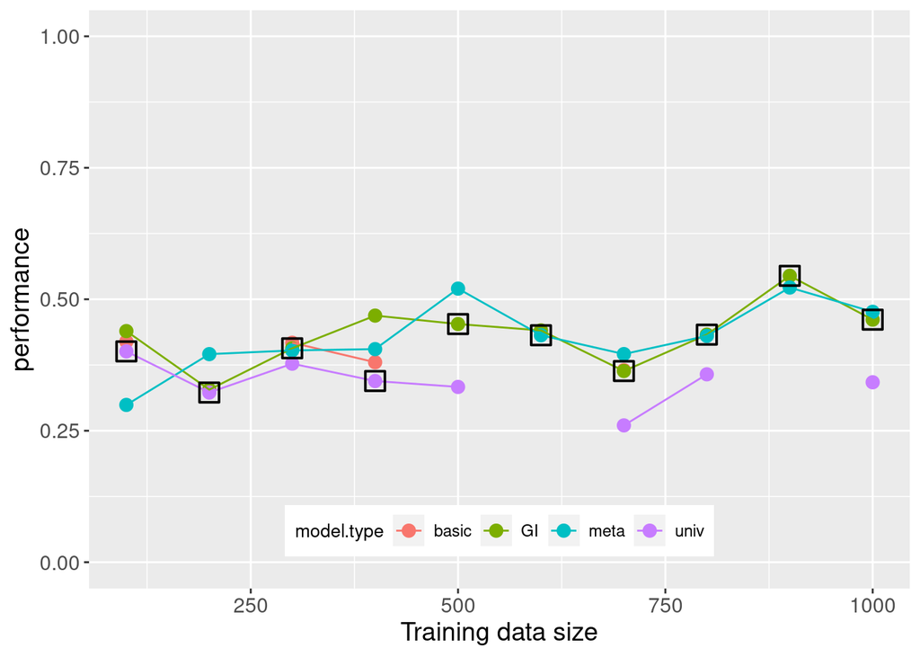

```r
g1 <- perfByModelType(d,x.label=variable.name)
g1
```

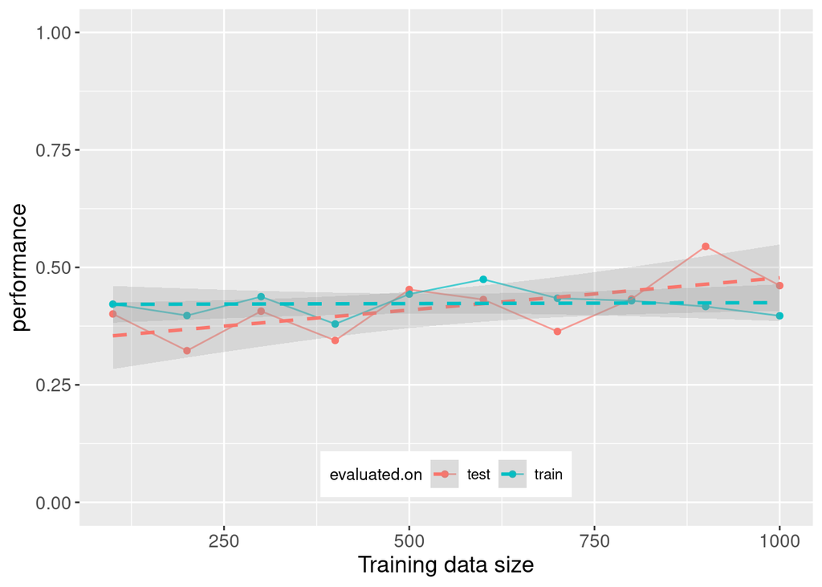

```r
g2 <- comparePerfsByEvalOn(d,diff.seen=FALSE,x.label=variable.name)
g2
```

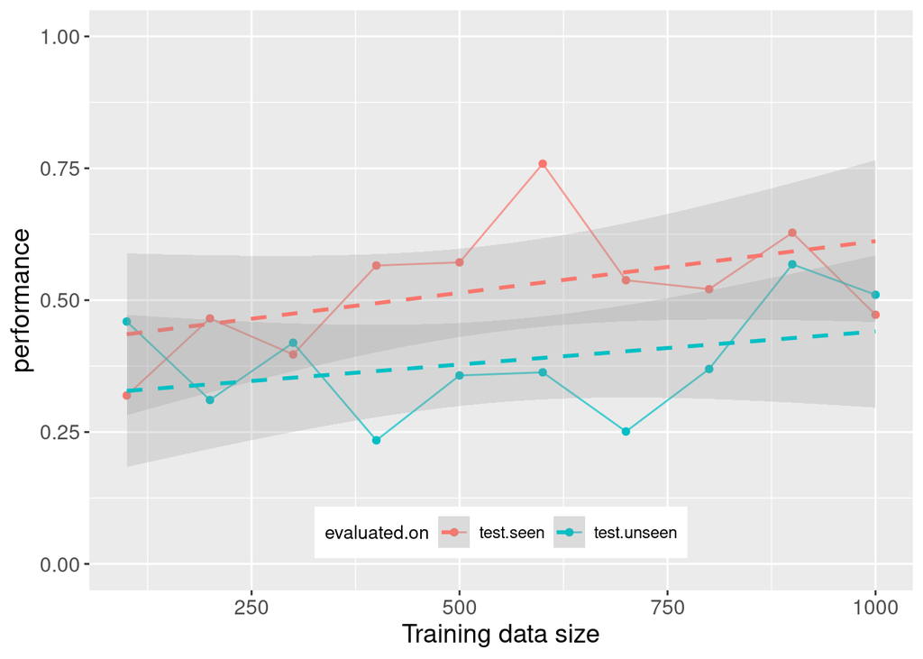

```r
g3 <- comparePerfsByEvalOn(d,diff.seen=TRUE,x.label=variable.name)
g3
```

```r
g<-plot_grid(g1,g2,g3,labels=NULL,ncol=3)
ggsave('graphs-expe3.pdf',g,width=30,height=8,unit='cm')
```